# Taller 6 - Homoterosdasticidad

Kevin Zarama - Cristhian Castillo

5/4/2021

Leer los datos del csv

```r
data <- read.csv('DatosTaller4.csv')
```

Realizar el modelo con los datos solicitados

```r
res1 <- lm(ViolentCrimesPerPop ~ racepctblack + pctUrban + PctPopUnderPov + MalePctDivorce + PctWorkMom + PctPersDenseHous + HousVacant + PctHousOccup + NumStreet, data)
```

Almacenar los datos de los residuales de el modelo

```r
e <- resid(res1)
```

Grafica de los residuos contra las variables del modelo

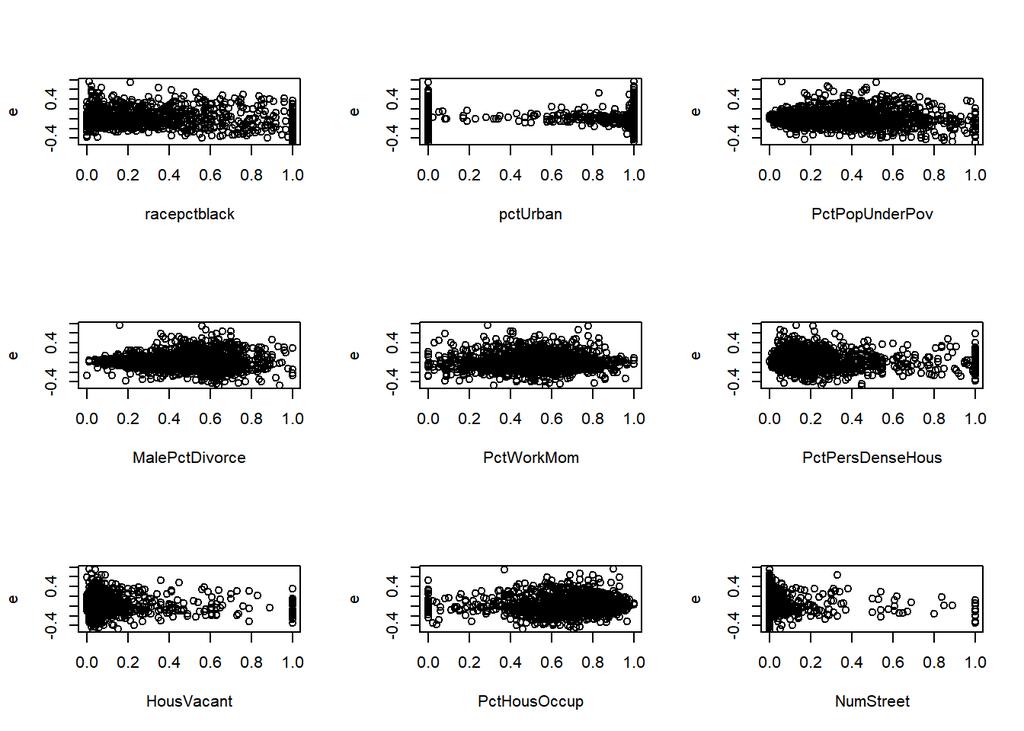

```r
attach(data)
par(mfrow=c(3,3))
plot(racepctblack, e)
plot(pctUrban, e)
plot(PctPopUnderPov, e)
plot(MalePctDivorce, e)
plot(PctWorkMom, e)
plot(PctPersDenseHous, e)
plot(HousVacant, e)
plot(PctHousOccup, e)
plot(NumStreet, e)
```

De las graficas se puede definir que las variables PctPopUnderPov, MalePctDivorce, PctPersDenseHous, HousVacant, PctHousOccup, NumStreet parece que puedan presentar heteroscedasticidad.

Para confirmar si existe heteroscedasticidad se van a realizar las pruebas de inferencia que determinan esto.

```r
bptest(res1, studentize = FALSE)
```

```
##
##  Breusch-Pagan test
##
## data:  res1
## BP = 667.27, df = 9, p-value < 2.2e-16
```

En este caso se puede rechazar la nula de homoscedasticidad en fabor de la alterna, por lo cual se dice que existe un problema de heterscedasticidad.

```r
ols_test_breusch_pagan(res1, rhs=TRUE, multiple=TRUE, p.adj='bonferroni')
```

```
##
##  Breusch Pagan Test for Heteroskedasticity
##  -----------------------------------------
##  Ho: the variance is constant
##  Ha: the variance is not constant
##
##                                                             Data
##  ----------------------------------------------------------------------------------------------------------------------------
##  Response : ViolentCrimesPerPop
##  Variables: racepctblack pctUrban PctPopUnderPov MalePctDivorce PctWorkMom PctPersDenseHous HousVacant PctHousOccup NumStreet
##
##             Test Summary (Bonferroni p values)
##  ------------------------------------------------------
##   Variable               chi2       df          p
##  ------------------------------------------------------
##   racepctblack        494.602261     1    1.278393e-108
##   pctUrban              1.250453     1     1.000000e+00
##   PctPopUnderPov      374.999986     1     1.373423e-82
##   MalePctDivorce      270.750057     1     7.009401e-60
##   PctWorkMom           16.479094     1     4.427053e-04
##   PctPersDenseHous    134.614277     1     3.608692e-30
##   HousVacant           43.701304     1     3.442651e-10
##   PctHousOccup        123.911690     1     7.926984e-28
##   NumStreet            24.481425     1     6.752672e-06
##  ------------------------------------------------------
##   simultaneous        667.269070     9    7.494331e-138
##  ------------------------------------------------------
```

Los resultados muestran que con un 99% de confianza podemos rechazar la hipotesis nula de homoscedastidad

```r
ols_test_normality(res1)
```

```
## -----------------------------------------------
##        Test             Statistic       pvalue
## -----------------------------------------------
## Shapiro-Wilk              0.9286         0.0000
## Kolmogorov-Smirnov        0.1121         0.0000
## Cramer-von Mises         512.6874        0.0000
## Anderson-Darling         44.0653         0.0000
## -----------------------------------------------
```

De lo anterior se puede concluir que los residuos no siguen una distribucion normal, por lo tanto los resultados no son confiables.

Se procedera a realizar otra prueba para determinar la hetereoscedasticidad.

```r
bptest(res1, studentize = TRUE)
```

```
##
##  studentized Breusch-Pagan test
##
## data:  res1
## BP = 260.24, df = 9, p-value < 2.2e-16
```

Si existe un problema de heteroscedasticidad

Prueba de White

```r
bptest(res1, ~ racepctblack + pctUrban + PctPopUnderPov + MalePctDivorce + PctWorkMom + PctPersDenseHous + HousVacant + PctHousOccup + NumStreet)
```

```
##
##  studentized Breusch-Pagan test
##
## data:  res1
## BP = 260.24, df = 9, p-value < 2.2e-16
```

Se puede rechazar la hipotesis nula de que existe un problema de homoscedasticidad, por lo cual podemos concluir que existe un problema de heteroscedasticidad.

## Solucion al problema de heteroscedasticidad con HC

```r
coeftest(res1, vcov = (vcovHC(res1, "HC4")))
```

```
##
## t test of coefficients:
##
##                    Estimate Std. Error t value  Pr(>|t|)
## (Intercept)      -0.0066509  0.0217258 -0.3061 0.7595381
## racepctblack      0.3819162  0.0216803 17.6158 < 2.2e-16 ***
## pctUrban          0.0461174  0.0087705  5.2582 1.611e-07 ***
## PctPopUnderPov    0.0810971  0.0212509  3.8162 0.0001397 ***
## MalePctDivorce    0.2992500  0.0211930 14.1203 < 2.2e-16 ***
## PctWorkMom       -0.0952741  0.0203630 -4.6788 3.080e-06 ***
## PctPersDenseHous  0.2722891  0.0224032 12.1540 < 2.2e-16 ***
## HousVacant        0.1374602  0.0400696  3.4305 0.0006147 ***
## PctHousOccup     -0.0475283  0.0215335 -2.2072 0.0274155 *
## NumStreet         0.1939173  0.0572749  3.3857 0.0007237 ***
## ---
## Signif. codes:  0 '***' 0.001 '**' 0.01 '*' 0.05 '.' 0.1 ' ' 1
```

De lo anterior se puede realizar el siguiente modelo, excluyendo a la variable PctHousOccup,

```r
res2 <- lm(ViolentCrimesPerPop ~ racepctblack + pctUrban + PctPopUnderPov + MalePctDivorce + PctWorkMom + PctPersDenseHous + HousVacant + NumStreet)
waldtest(res2, res1, vcov=vcovHC(res1))
```

```
## Wald test
##
## Model 1: ViolentCrimesPerPop ~ racepctblack + pctUrban + PctPopUnderPov +
##     MalePctDivorce + PctWorkMom + PctPersDenseHous + HousVacant +
##     NumStreet
## Model 2: ViolentCrimesPerPop ~ racepctblack + pctUrban + PctPopUnderPov +
##     MalePctDivorce + PctWorkMom + PctPersDenseHous + HousVacant +
##     PctHousOccup + NumStreet
##   Res.Df Df      F  Pr(>F)
## 1   1985
## 2   1984  1 4.9442 0.02629 *
## ---
## Signif. codes:  0 '***' 0.001 '**' 0.01 '*' 0.05 '.' 0.1 ' ' 1
```